**City College of San Francisco**

MATH 108 - Foundations of Data Science

# Lecture 26: Confidence Intervals

Associated Textbook Sections: [13.0, 13.1, 13.2](https://inferentialthinking.com/chapters/13/Estimation.html)

## Outline

- Percentiles
- Estimation
- The Bootstrap
- Confidence Intervals

## Set Up the Notebook

```python
from datascience import *
import numpy as np
%matplotlib inline
import matplotlib.pyplot as plt
plt.style.use('fivethirtyeight')
```

## Percentiles

### Computing Percentiles

The Xth percentile is first value on the sorted list that is at least as large as X% of the elements.

- The 80th percentile of `[1, 7, 3, 9, 5]` is the 4th ordered (`[1, 3, 5, 7, 9]`) element, 7:
- The 4th element is used because $(80/100) \cdot 5 = 4$
- For a percentile that does not exactly correspond to an element, take the next greater element instead

### The percentile Function

- The pth percentile is the smallest value in a set that is at least as large as p% of the elements in the set
- Function in the datascience module: `percentile(p, values)`
  - `p` is between 0 and 100
  - `values` is an array, list, etc.
  - Returns the pth percentile of the array
- `percentile(80, s)` returns `7`

### Demo: Percentiles

Compute the 55th percentile of the following array.

```python
x = make_array(43, 20, 51, 7, 28, 34)
```

```python
percentile(55, x)
```

```
34
```

Sort the array

```python
np.sort(x)   # first, sort from smallest to largest
```

```
array([ 7, 20, 28, 34, 43, 51])
```

```python
percentile(50, x)
# np.median(x)
```

```
28
```

Calculate the value of the index corresponding to the percentile. Round up the value.

```python
# to get which element is the 55th percentile, compute which element
# it would be in the sorted list, round up (so here it would be the 4th element in the sorted list = 34.

55/100 * len(x)
```

```
3.3000000000000003
```

## Estimation

### Inference: Estimation

How do we calculate the value of an unknown parameter?

- If you have a census (that is, the whole population): Just calculate the parameter and you're done
- If you don't have a census:
  - Take a random sample from the population
  - Use a statistic as an estimate of the parameter

### Demo: Sample Median Estimation

Load the [2022 Employee Compensation data from data.sfgov.org](https://data.sfgov.org/City-Management-and-Ethics/Employee-Compensation/88g8-5mnd).

```python
sf = Table.read_table('https://data.sfgov.org/resource/88g8-5mnd.csv?year=2022')
sf.show(3)
```

| organization_group_code | job_family_code | job_code | year_type | year | organization_group | department_code | department | union_code | union | job_family | job | employee_identifier | salaries | overtime | other_salaries | total_salary | retirement | health_and_dental | other_benefits | total_benefits | total_compensation |
| --- | --- | --- | --- | --- | --- | --- | --- | --- | --- | --- | --- | --- | --- | --- | --- | --- | --- | --- | --- | --- | --- |
| 2 | 1400 | 1402 | Fiscal | 2022 | Public Works, Transportation & Commerce | DPW | Department Of Public Works | 790 | SEIU, Local 1021, Misc | Clerical, Secretarial & Steno | Junior Clerk | 50347320 | 26708.2 | 0 | 0 | 26708.2 | 6323.99 | 0 | 2165.3 | 8489.29 | 35197.5 |
| 1 | H000 | H002 | Fiscal | 2022 | Public Protection | FIR | Fire Department | 798 | Firefighters,Local 798, Unit 1 | Fire Services | Firefighter | 47372048 | 129217 | 42520.2 | 35791.1 | 207528 | 31434.2 | 0 | 3179.66 | 34613.8 | 242142 |
| 1 | H000 | H003 | Fiscal | 2022 | Public Protection | FIR | Fire Department | 798 | Firefighters,Local 798, Unit 1 | Fire Services | EMT/Paramedic/Firefighter | 47370369 | 22343.9 | 0 | 1187.58 | 23531.5 | 4820.27 | 0 | 301.4 | 5121.67 | 28653.1 |

... (997 rows omitted)

Reduce the table to the `job`, `total_salary`, and `total_compensation` columns.

```python
sf = sf.select('job', 'total_salary', 'total_compensation')
sf.show(3)
```

| job | total_salary | total_compensation |
| --- | --- | --- |
| Junior Clerk | 26708.2 | 35197.5 |
| Firefighter | 207528 | 242142 |
| EMT/Paramedic/Firefighter | 23531.5 | 28653.1 |

... (997 rows omitted)

Who is making the most money?

```python
sf.sort('total_compensation', descending=True).show(5)
```

| job | total_salary | total_compensation |
| --- | --- | --- |
| Captain, Fire Suppression | 457506 | 503102 |
| Battalion Chief, Fire Suppress | 370590 | 422595 |
| Deputy Chief 3 | 335520 | 419042 |
| Physician Specialist | 349289 | 413827 |
| Lieutenant, Fire Suppression | 345260 | 387744 |

... (995 rows omitted)

Visually explore the distribution of compensations.

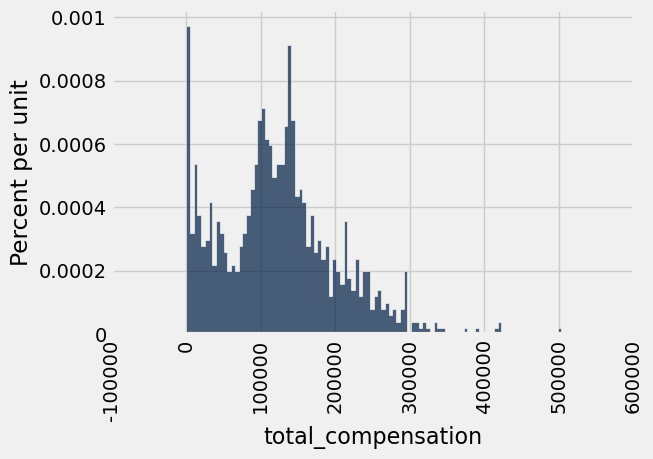

```python
sf.hist('total_compensation', bins=100)    # bins = 100 makes a more fine-grained plot
```

Filter out the bottom 5% and top 5% of compensations.

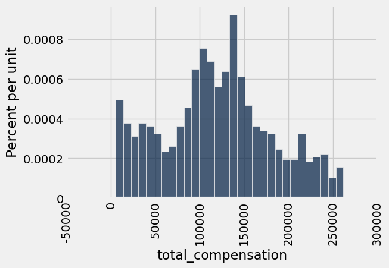

```python
bottom_5 = percentile(5, sf.column('total_compensation'))
top_5 = percentile(95, sf.column('total_compensation'))
sf = sf.where('total_compensation', are.between_or_equal_to(bottom_5, top_5))
sf.select('total_compensation').hist(bins=30)
```

Calculate the median total compensation of this population.

```python
pop_median = np.median(sf.column('total_compensation'))
pop_median

# or percentile(50, sf.column('total_compensation')) would also do it
```

```
119222.34
```

Randomly sample 300 employees from the population and calculate the sample median total compensation.

```python
our_sample = sf.sample(300, with_replacement=False)    # without replacement
our_sample.show(5)
```

| job | total_salary | total_compensation |
| --- | --- | --- |
| Special Nurse | 130733 | 136293 |
| Registered Nurse | 144964 | 171411 |
| IS Project Director | 180795 | 228975 |
| Special Nurse | 156532 | 178452 |
| Public SafetyComm Disp | 53918.7 | 68159.5 |

... (295 rows omitted)

```python
np.median(our_sample.column('total_compensation'))
```

```
121598.35500000001
```

Visually compare the distribution of total compensation values for the population and random sample.

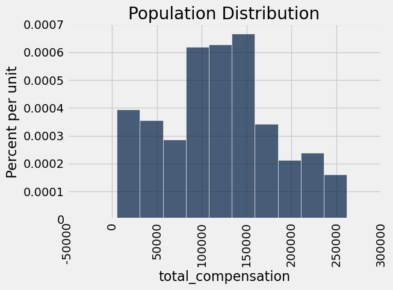

```python
sf.hist('total_compensation', bins=10)
plt.title('Population Distribution');
```

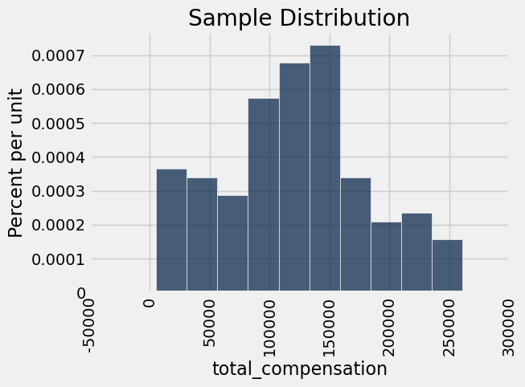

```python
our_sample.hist('total_compensation', bins=10)
plt.title('Sample Distribution');
```

### Variability of the Estimate

- One sample $\implies$ One estimate
- But the random sample could have come out differently
- And so the estimate could have been different
- **Big question**: How different would it be if we did it again?

### Demo: Variability of the Estimate

Create a function that samples randomly from the `sf` table and returns the sample median for `total_compensation`.

```python
def generate_sample_median(samp_size):
    our_sample = sf.sample(samp_size, with_replacement = False)
    return np.median(our_sample.column('total_compensation'))
```

```python
sample_median = generate_sample_median(300)
sample_median
```

```
128397.95
```

Compute the error if the sample median is used to estimate the population median for total compensation. Re-run the above function to see how the error varies.

```python
error = sample_median - pop_median
error
```

```
9175.6100000000006
```

### Quantifying Uncertainty

- The estimate is usually not exactly right: `Estimate = Parameter + Error`
- How accurate is the estimate, usually?
- How big is a typical error?
- When we have a census, we can do this by simulation

### Demo: Quantifying Uncertainty

```python
sample_medians = make_array()

for i in np.arange(1000):
    new_median = generate_sample_median(300)
    sample_medians = np.append(sample_medians, new_median)
```

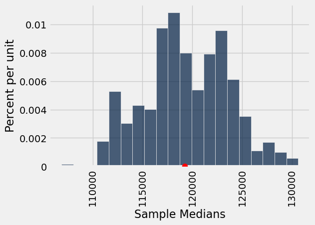

```python
Table().with_column(
    'Sample Medians', sample_medians
).hist(bins = 20)

plt.scatter(pop_median, 0, color="red", s=60, zorder=3);
```

Visualize the distribution of errors found from using the sample medians to estimate the population median.

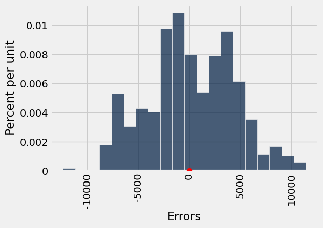

```python
Table().with_column(
    'Errors', sample_medians - pop_median
).hist(bins=20)

plt.scatter(0, 0, color="red", s=60, zorder=3);
```

### Where to Get Another Sample?

- We want to understand errors of our estimate
- Given the population, we could simulate... but we only have the sample!
- To get many values of the estimate, we needed many random samples
- We can't go back and sample again from the population:
  - No time, no money
  - Stuck?

## The Bootstrap

### The Bootstrap

- A technique for simulating repeated random sampling
- All that we have is the original sample... which is large and random
- Therefore, it probably resembles the population
- So we sample at random from the original sample!

### Why the Bootstrap Works

All of the resamples look pretty **similar**, most likely.

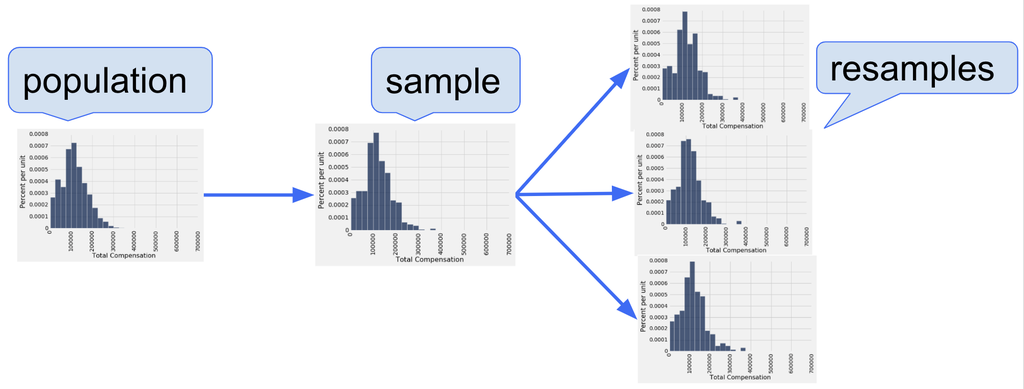

### Why We Need the Bootstrap

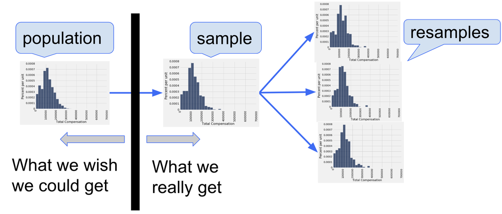

### The Bootstrap Principle

- The bootstrap principle: Bootstrap-world sampling $\approx$ Real-world sampling
- Not always true! ... but reasonable if sample is large enough
- We hope that the following are similar to what they are in the real world
  - Variability of bootstrap estimate
  - Distribution of bootstrap errors

### Key to Resampling

- From the original sample,
  - draw at random
  - with replacement
  - as many values as the original sample contained
- The size of the new sample has to be the same as the original one, so that the two estimates are comparable

### The Bootstrap Process

#### One Random Sample

True but unknown distribution (population) → Random sample (the original sample)

#### Bootstrap

Empirical distribution of original sample (“population”) → Bootstrap sample 1

- → Estimate 1
- → Bootstrap sample 2
- → Estimate 2
- ...
- → Bootstrap sample 1000
- → Estimate 1000

### Demo: Bootstrap

Take a bootstrap (re)sample (**WITH replacement**) of size 300 from the last sf sample.

```
Population Median =        119222.34
Our Sample Median =        128397.95
Bootstrap Sample Median =  117540.5
```

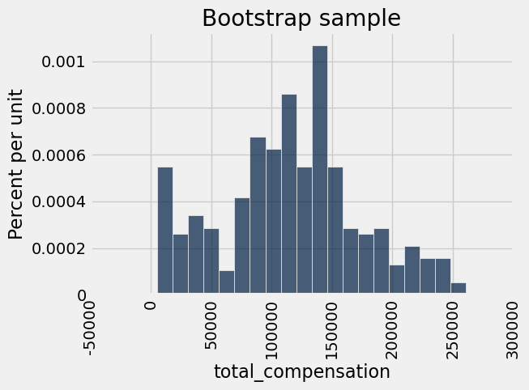

```python
boot_sample = our_sample.sample(300, True)
boot_sample.hist('total_compensation', bins=20)
plt.title('Bootstrap sample');

print("Population Median =       ", pop_median)
print("Our Sample Median =       ", sample_median)
print("Bootstrap Sample Median = ",
      np.median(boot_sample.column('total_compensation')))
```

```python
def one_bootstrap_median():
    boot_sample = our_sample.sample(300, True)
    return np.median(boot_sample.column('total_compensation'))
```

```python
boot_medians = make_array()

for i in np.arange(10000):
    one_boot_med = one_bootstrap_median()
    boot_medians = np.append(boot_medians , one_boot_med)
```

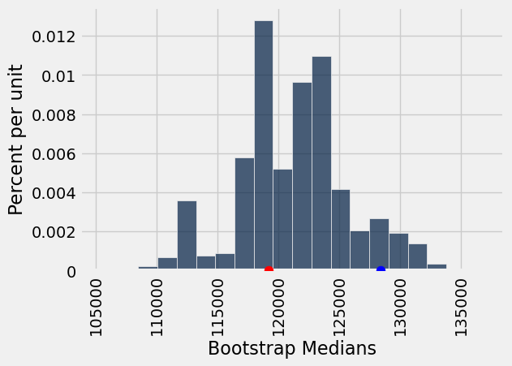

```python
Table().with_column(
    'Bootstrap Medians', boot_medians
).hist('Bootstrap Medians', bins=20)

plt.scatter(pop_median, 0, color="red", s=60, zorder=3);
plt.scatter(sample_median, 0, color="blue", s=60, zorder=3);
```

## Confidence Intervals

### 95% Confidence Interval

- Interval of estimates of a parameter
- Based on random sampling
- 95% is called the confidence level
  - Could be any percent between 0 and 100
  - Higher level means wider intervals
- The confidence is in the process that gives the interval: It generates a "good" interval about 95% of the time.

### Demo: Confidence Intervals

Make an interval based on the middle 95% of bootstrap samples.

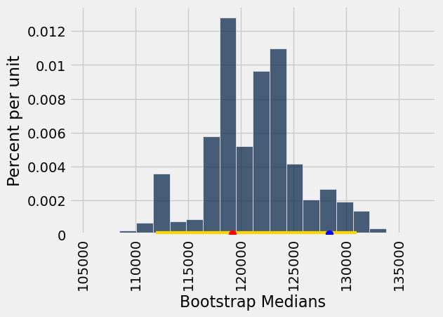

```python
left = percentile(2.5, boot_medians)
right = percentile(97.5, boot_medians)

Table().with_column(
    'Bootstrap Medians', boot_medians
).hist('Bootstrap Medians', bins=20)

plt.plot([left, right], [0,0], color="gold",lw=6, zorder=3);
plt.scatter(pop_median, 0, color="red", s=60, zorder=4);
plt.scatter(sample_median, 0, color="blue", s=60, zorder=4);
```